# Homework2

第9组

2020/4/9

**1. 首先载入各种包（已略去token），并且调用中国平安的股票与上证、深证及港股的全体股票代码。**

```r
pacman::p_load(Tushare,tidyverse,tidyquant,DT,anytime,corrplot)
```

```r
zgpa <- bar(ts_code='601318.SH',start_date="20140101",
                end_date='20200407',adj="qfq")

code_cn <- api(api_name = 'stock_basic')
code_hk <- api(api_name = 'hk_basic')
```

**2. 我们将股票价格中存在缺失值的行删去，并使用for循环对上证和深证股票共3806支股票进行检索，发现只有002506.SZ的日收益率与中国平安呈负相关。由于耗时较长，此处仅展示代码，不再运行。**

```
stock_negative <- list()
corr <- list()

for (i in code_cn$ts_code){
stock_negative[[i]] <- bar(ts_code=i,start_date="20140101",
                end_date='20200407',adj="qfq")
corr[[i]] <- rbind(zgpa,stock_negative[[i]]) %>%
  select(ts_code,trade_date,close) %>%
  mutate(trade_date = as.Date(trade_date,format="%Y%m%d"),close = as.numeric(close)) %>%
  group_by(ts_code) %>%
  tq_transmute(
    select=close,
    mutate_fun=dailyReturn,
    col_rename='day_returns'
  ) %>%
  pivot_wider(names_from='ts_code',values_from='day_returns') %>%
  select(-trade_date) %>%
  na.omit()%>%
  cor()
}
```

**3. 下图展示了002506.SZ的股价时间序列图，可以发现2014-1015年间有很大缺失值，不能说明该股票日收益率在2014-2020间与中国平安呈负相关。因此还需要寻找其他股票。**

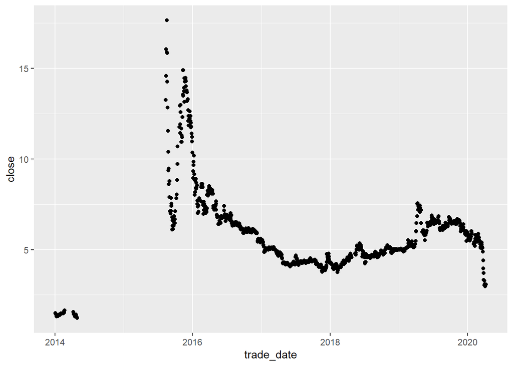

```r
xxjc <- bar(ts_code='002506.SZ',start_date="20140101",
                end_date='20200407',adj="qfq") %>%
  mutate(trade_date = as.Date(trade_date,format="%Y%m%d"),close = as.numeric(close))
ggplot(xxjc,aes(x=trade_date,y=close)) + geom_point()
```

```r
jxgj <- api(api_name='hk_daily',ts_code='00091.HK',start_date="20140101",
                end_date='20200407',adj="qfq")
jhjt <- api(api_name='hk_daily',ts_code='00115.HK',start_date="20140101",
                end_date='20200407',adj="qfq")
zgbl <- api(api_name='hk_daily',ts_code='00164.HK',start_date="20140101",
                end_date='20200407',adj="qfq")
```

[output not shown]

**5.下图展示了三只港股价格的箱线图**

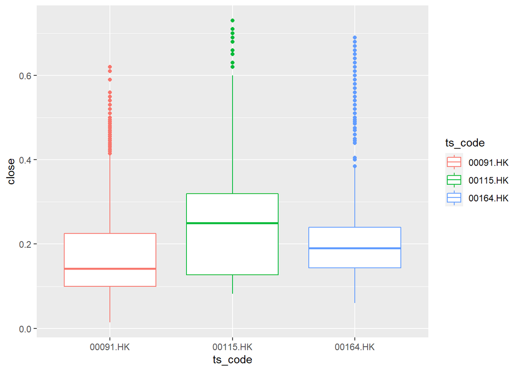

```r
df <- rbind(zgpa,jxgj,jhjt,zgbl) %>%
  mutate(trade_date = as.Date(trade_date,format="%Y%m%d"),
        close = as.numeric(close))

ggplot(filter(df,ts_code!="601318.SH"),
       aes(x=ts_code,y=close,color=ts_code)) +
  geom_boxplot()
```

**6. 下表和图展示了三只港股与中国平安年度收益率的情况。**

```r
df <- df %>%
  select(ts_code,trade_date,close) %>%
  group_by(ts_code) %>%
  tq_transmute(
    select=close,
    mutate_fun=yearlyReturn
  ) %>%
  mutate(id=ifelse(ts_code!="601318.SH","港股","中国平安"))

df %>% select(-id) %>% datatable()
```

|  | ts_code | trade_date | yearly.returns |
| --- | --- | --- | --- |
| 1 | 601318.SH | 2014-12-31 | 0.840958605664488 |
| 2 | 601318.SH | 2015-12-31 | -0.0242603550295858 |
| 3 | 601318.SH | 2016-12-30 | 0.000606428138265613 |
| 4 | 601318.SH | 2017-12-29 | 1.01393939393939 |
| 5 | 601318.SH | 2018-12-28 | -0.174842010231718 |
| 6 | 601318.SH | 2019-12-31 | 0.558351568198395 |
| 7 | 601318.SH | 2020-04-07 | -0.181254388017786 |
| 8 | 00091.HK | 2014-12-31 | 1.62295081967213 |
| 9 | 00091.HK | 2015-12-31 | -0.575 |
| 10 | 00091.HK | 2016-12-30 | -0.264705882352941 |

[output cut: 17 more lines]

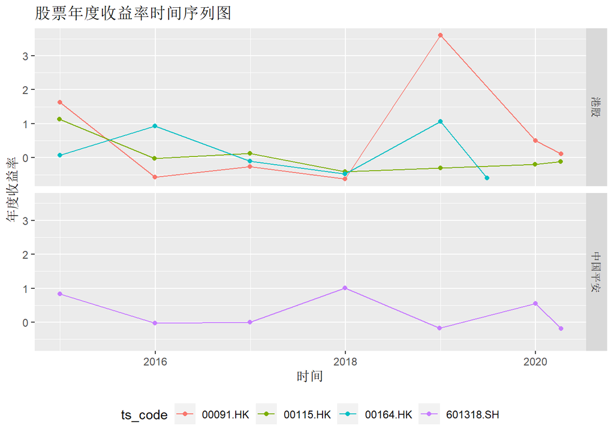

```r
p <- ggplot(df,aes(x=trade_date,yearly.returns,color=ts_code))
p + geom_line() +
  geom_point() +
  labs(x="时间",y="年度收益率") +
  ggtitle("股票年度收益率时间序列图") +
  facet_grid(id~.) +
  theme(legend.position = "bottom")
```

**7. 下表为三只股票年度收益率的标准差。**

```r
df %>%
  group_by(ts_code) %>%
  filter(id!="中国平安") %>%
  summarise(sd_return = sd(yearly.returns)) %>%
  datatable()
```

|  | ts_code | sd_return |
| --- | --- | --- |
| 1 | 00091.HK | 1.52173248467354 |
| 2 | 00115.HK | 0.516221054497242 |
| 3 | 00164.HK | 0.701596312493799 |

```r
df %>%
  group_by(ts_code) %>%
  drop_na()%>%
  mutate(cr=cumprod(1+yearly.returns)) %>%
  mutate(cumulative_returns=cr-1) %>%
  select(ts_code,trade_date,cumulative_returns) %>%
  datatable()
```

|  | ts_code | trade_date | cumulative_returns |
| --- | --- | --- | --- |
| 1 | 601318.SH | 2014-12-31 | 0.840958605664488 |
| 2 | 601318.SH | 2015-12-31 | 0.796296296296296 |
| 3 | 601318.SH | 2016-12-30 | 0.797385620915033 |
| 4 | 601318.SH | 2017-12-29 | 2.619825708061 |
| 5 | 601318.SH | 2018-12-28 | 1.98692810457516 |
| 6 | 601318.SH | 2019-12-31 | 3.65468409586057 |
| 7 | 601318.SH | 2020-04-07 | 2.81100217864924 |
| 8 | 00091.HK | 2014-12-31 | 1.62295081967213 |
| 9 | 00091.HK | 2015-12-31 | 0.114754098360656 |
| 10 | 00091.HK | 2016-12-30 | -0.180327868852459 |

[output cut: 17 more lines]